# Programacion en R

#### Modificar la apariencia de las visualizaciones

Con la estética podemos cambiar la apariencia de nuestros datos en la visualizacion que estamos crando. Existen tres atributos básicos a tener en cuenta al crear visualizaciones de datos.

La estética se define como una propiedad visual de un objeto de tu diagrama y los tres atributos eséticos son los siguientes:

- color
- tamaño
- forma
- color: te permite modificar el color de todos los puntos de tu diagrama o el color de cada grupo de datos.

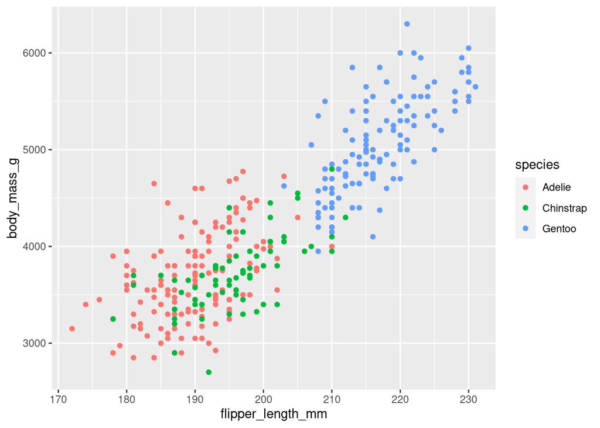

```r
ggplot(data=penguins) + geom_point(mapping = aes(x=flipper_length_mm,
                                                 y=body_mass_g,
                                                 color=species))
```

En el bloque anterior decimos que cambie el color por cada especie diferente.

- tamaño: te permite modificar el tamaño de los puntos de tu diagrama por grupo de datos
- forma: te permite modificar la forma de los puntos de tu diagrama por grupo de datos

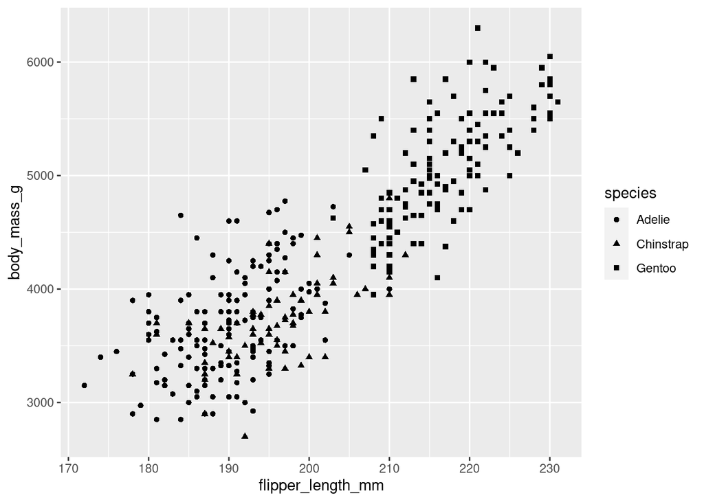

```r
ggplot(data=penguins) + geom_point(mapping = aes(x=flipper_length_mm,
                                                 y=body_mass_g,
                                                 shape=species))
```

Aqui destacamos las diferentes especies usando diferentes formas geometricas aplicando la variable especies a la estetica shape

Podemos **aplicar más de una estetica a una misma variable**

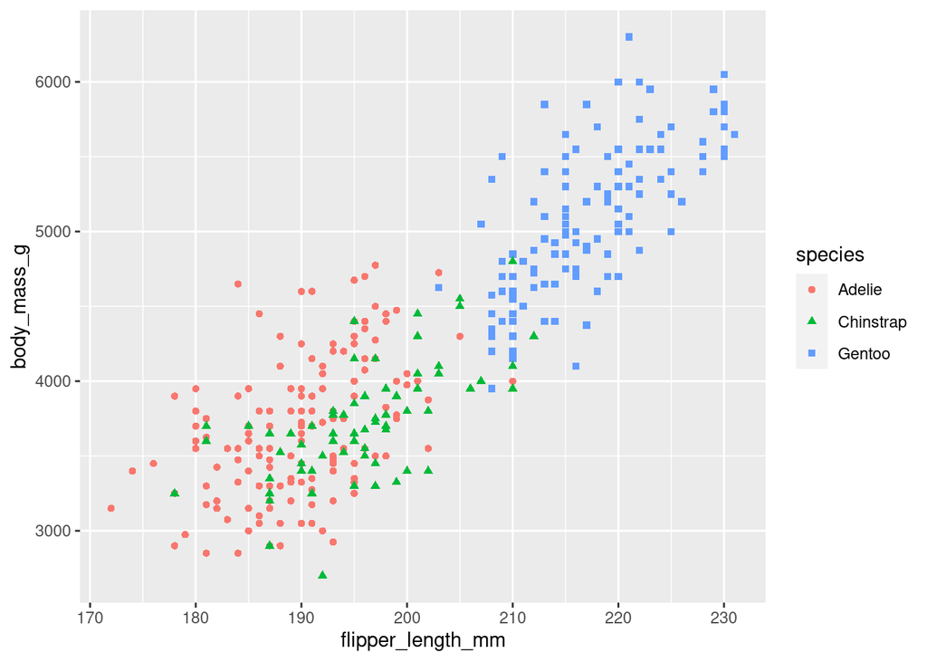

```r
ggplot(data=penguins) + geom_point(mapping = aes(x=flipper_length_mm,
                                                 y=body_mass_g,
                                                 shape=species, color=species))
```

**Aplicando las tres esteticas**

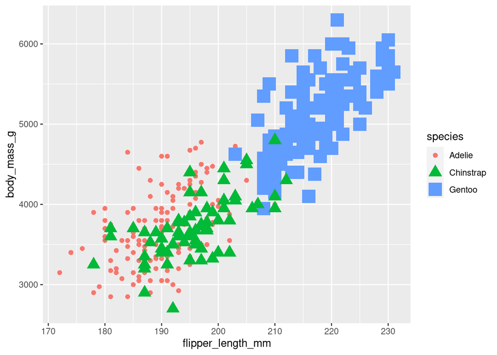

```r
ggplot(data=penguins) + geom_point(mapping = aes(x=flipper_length_mm,
                                                 y=body_mass_g,
                                                 shape=species,
                                                 color=species,
                                                 size=species))
```

- estetica alpha Esta estetica mapaea nuestros datos con la estetica alfa que controla la transparencia de los puntos.

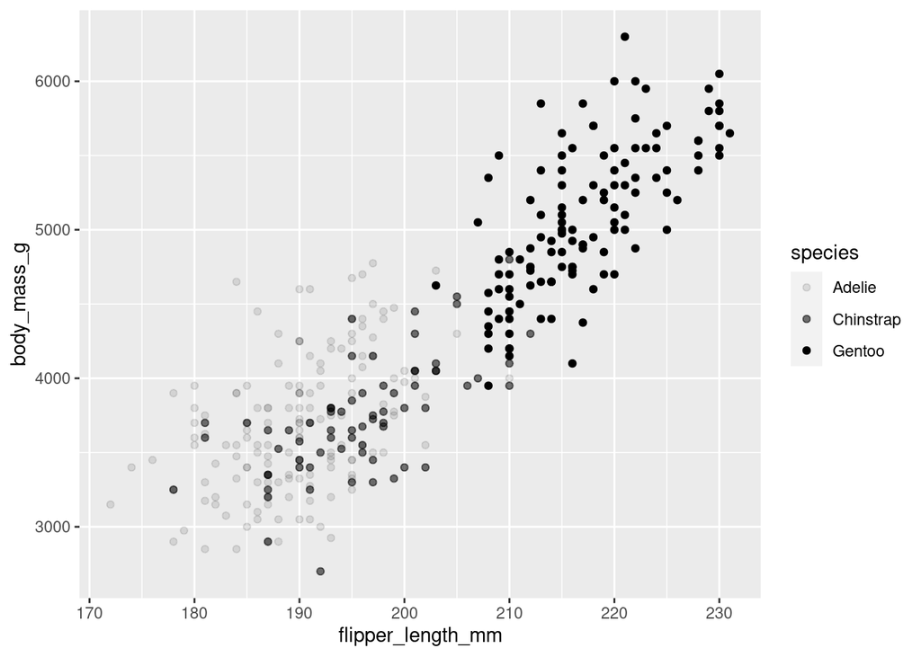

```r
ggplot(data=penguins) + geom_point(mapping = aes(x=flipper_length_mm,
                                                 y=body_mass_g,
                                                 alpha=species))
```

Todo lo relacionado con la estetica de nuestro conjunto de datos ira dentro de la funcion ‘aes()’, definir los ejes x e y son parte de la estetica. Como se mencionó, modificar el color, tamaño y forma es parte de la estetica, por lo que si deseamos modificarlos iran dentro de la función mecionada.

Con la funcion **aes**, tambien mapeamos nuestros datos lo que significa emparejar una variable especifica en tu conjunto de datos con una estética especifica.

Podemos fijar una estetica por separado de una variable especifica. Digamos que queremos cambiar el color de tosos los puntos a violeta. Pero no queremos aplicar color a una variable especifica como especia. Solo queremos que cada punto de nuestro diagrama de dispersion sea violeta. Para lograrlo debemos colocar nuestro nuevo trozo de codigo fuera de la funcion aes y usar comillas para nuestro valor de color.

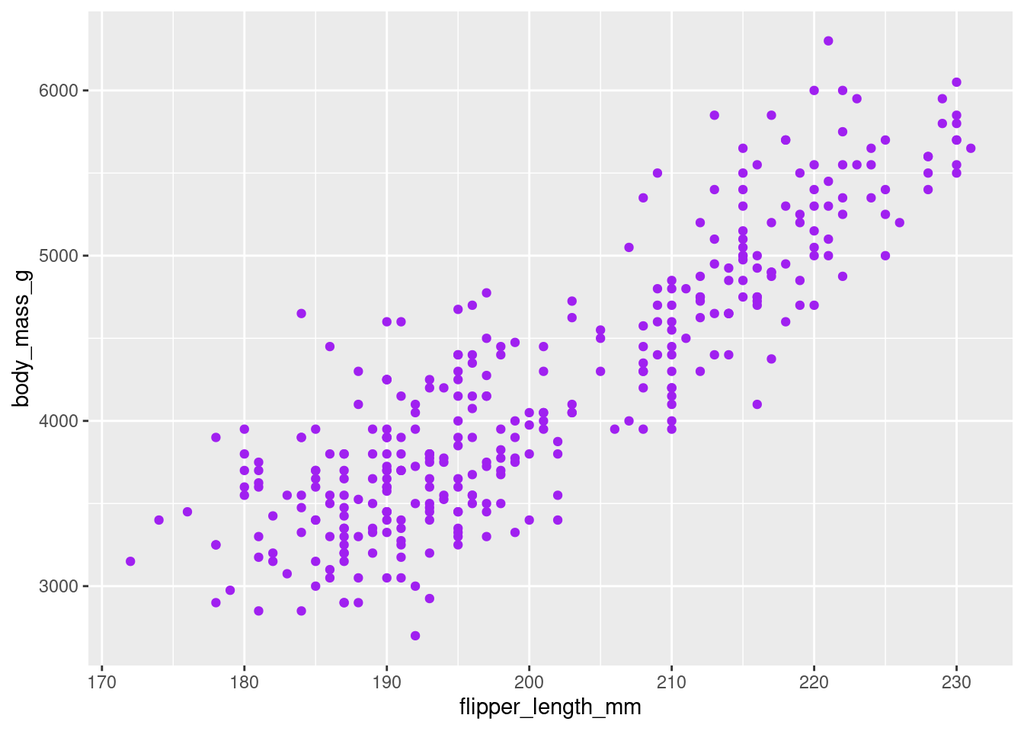

```r
ggplot(data=penguins) + geom_point(mapping = aes(x=flipper_length_mm,
                                                 y=body_mass_g,),
                                   color='purple')
```

- Usando diferentes funciones geometricas

Anteriormente nos hemos centrado en los gráficos de dispersión de puntos, pero existen diferentes gráficos que se pueden usar en ggplot al modificar las figuras geometricas que representaran a nuestros datos.

En ggplot2 una figura geométrica es un objeto geométrico usado para representar a nuestros datos. Las figuras geometricas incluyen puntos, barras, lineas, etc.

#### geom functions

- geom_point(): Para graficos de dispersion de puntos
- geom_bar(): Para gráficos de barras
- geom_line(): Para graficos de linea
- geom_smoot(): Grafica con linea suavizada
- geom_jttler(): Crea diagramas de dispersión y luego agrega una pequeña cantidad de ruido aleatorio, ayuda a lidiar con el trazado excesivo, que sucede cuando los puntos de datos de un diagrama se super ponen unos con otros.

Para modificar la figura geometrica a utilizar es necesario modificar la funcion geom en el codigo. Si queremos modificar el grafico de dispersion que mostraba la relacion entre las variables flliper_length_mm y body_mass_g por una grafica con una linea suave podemos hacerlo como sigue:

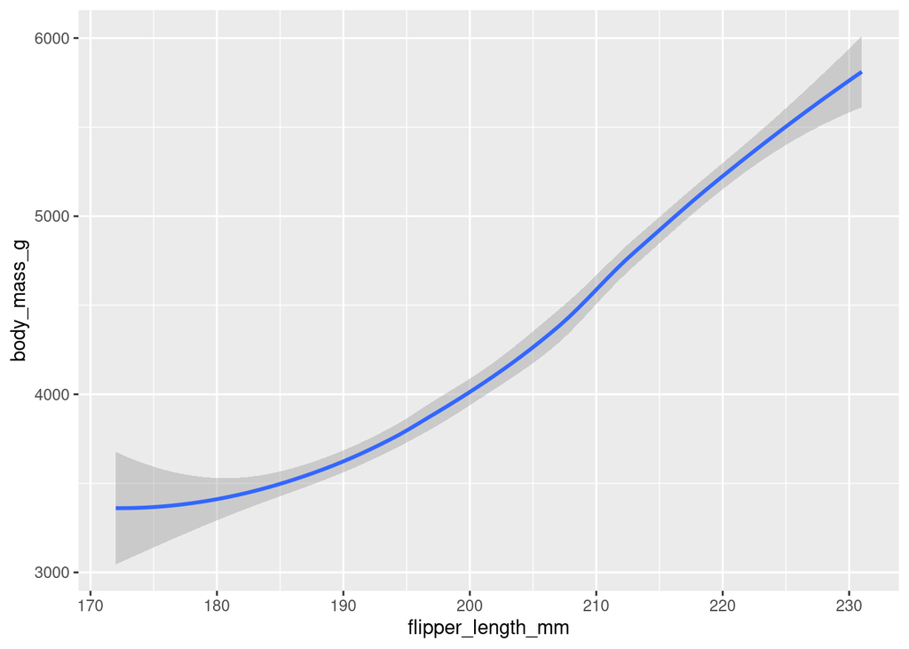

```r
ggplot(data=penguins) + geom_smooth(mapping = aes(x=flipper_length_mm,
                                                y=body_mass_g))
```

La funcion geom_smooth es util para mostrar tendencias generales en nuestros datos. La linea muestra con laridad la relación positiva entre nuestras variables.

Podemos combinar diferentes geometrias, supongamos que deseamos mostrar tanto la tendencia general y los puntos individuales de nuestros datos.

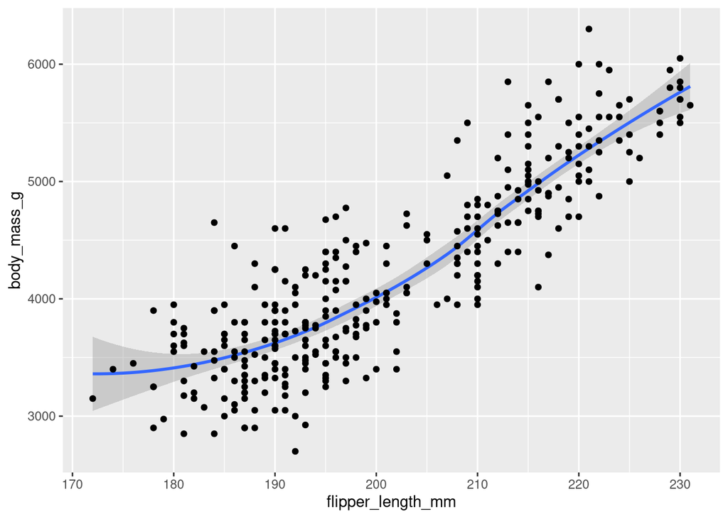

```r
ggplot(data=penguins) +
  geom_smooth(mapping = aes(x=flipper_length_mm,
                            y=body_mass_g)) +
  geom_point(mapping = aes(x=flipper_length_mm,
                           y=body_mass_g))
```

Digamos que ahora queremos modelar una linea separada para cada especie

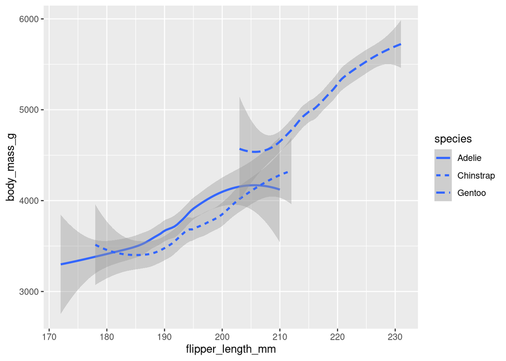

```r
ggplot(data=penguins) +
  geom_smooth(mapping = aes(x=flipper_length_mm,
                            y=body_mass_g, linetype=species))
```

El bloque anterior agrega la estetica linetype para que a cada especie de pinguino le asigne una tipo de linea y una linea suavizada diferente.

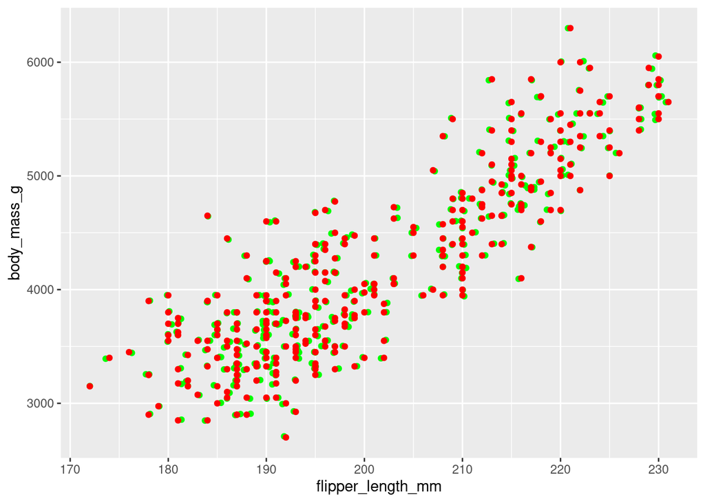

```r
ggplot(data=penguins) +
  geom_jitter(mapping = aes(x=flipper_length_mm, y=body_mass_g), color='green') +
  geom_point(mapping = aes(x=flipper_length_mm, y=body_mass_g), color='red')
```

Con el codigo anterior comparamos las geometrias jitter y point.

##### Graficas de barras

Para ejemplificar su uso, utilizaremos el conjunto de datos de diamantes, incluidos en ggplot2

```r
data("diamonds")
View(diamonds)
```

- Creacion de un grafico de barras (vertical)

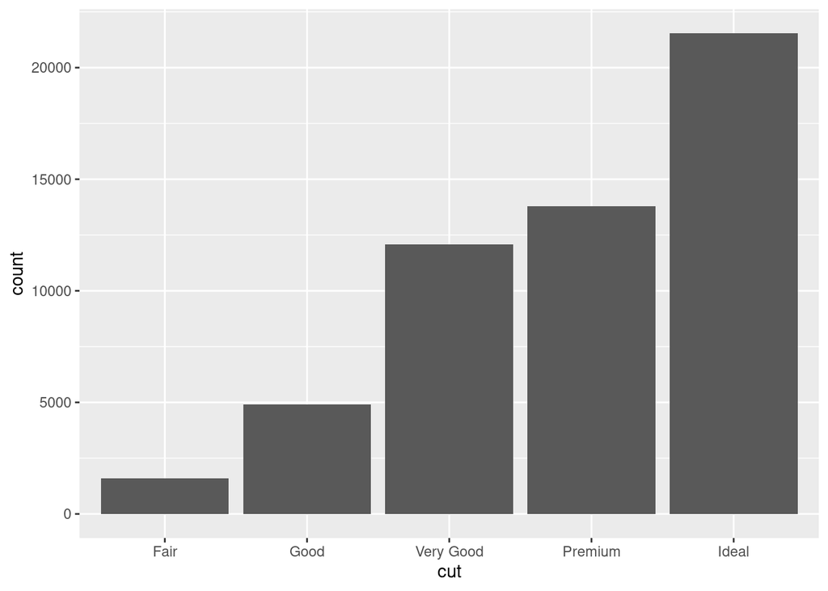

```r
ggplot(data=diamonds) +
  geom_bar(mapping = aes(x=cut))
```

- Creacion de un grafico de barras (horizontal)

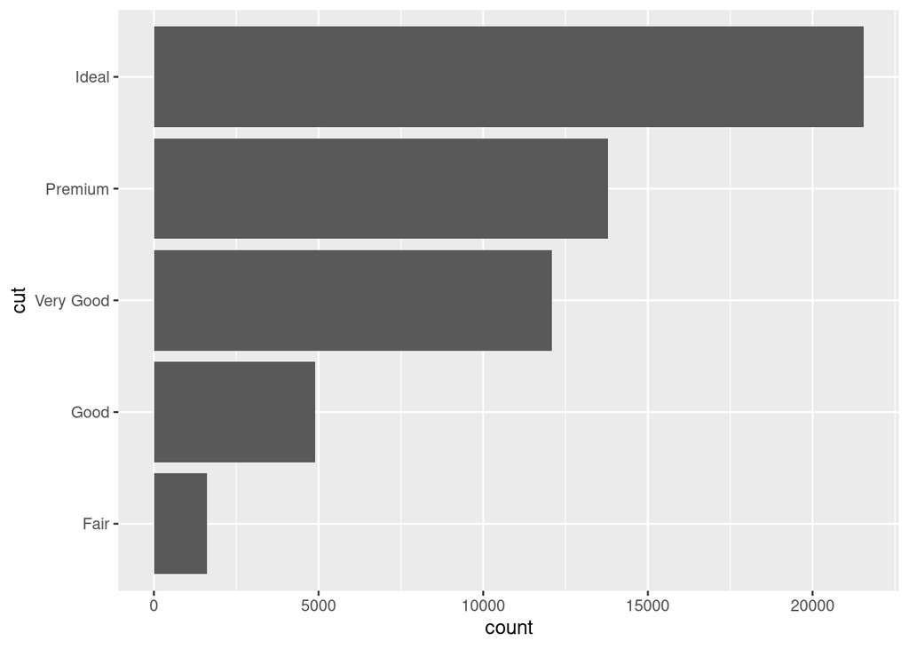

```r
ggplot(data=diamonds) +
  geom_bar(mapping = aes(y=cut))
```

Cuando solo especificamos solo un eje para un grafico de barras, R de manera automatica completa el otro eje con el conteo de observaciones para las categorias existentes en el eje que si se ha especificado.

Esta geometria utiliza las diversas esteticas que hemos mencionado anteriormente, teniendo algunas particularidades como es la estetica fill

Apliquemos la estetica color a la variable cut:

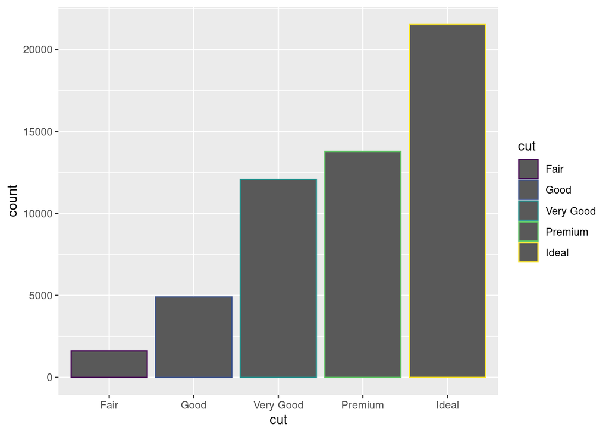

```r
ggplot(data=diamonds) +
  geom_bar(mapping = aes(x=cut, color=cut))
```

El codigo anterior aplica color pero solo a los contronos de nuestras barras, si queremos que el color se aplique tambien en el relleno (que es lo mas comun), podemos usar la estetica fill

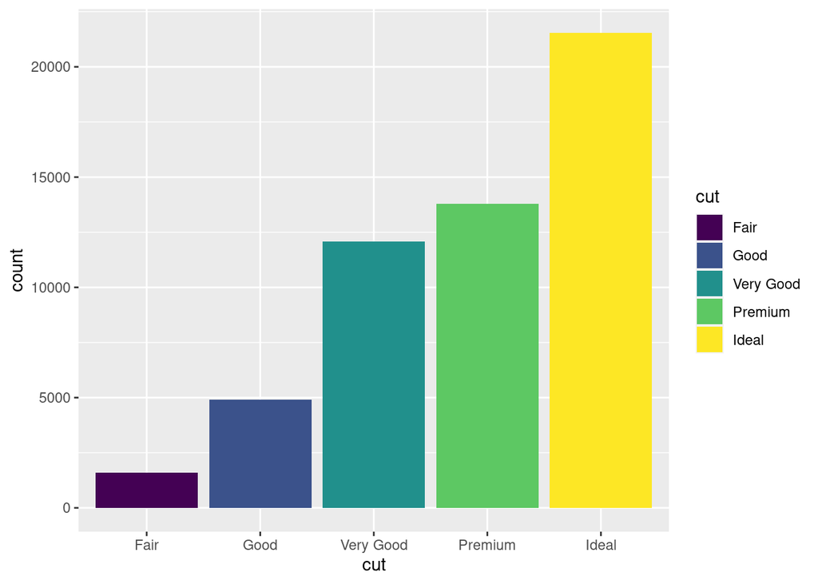

```r
ggplot(data=diamonds) +
  geom_bar(mapping = aes(x=cut, fill=cut))
```

En este ultimo ejemplo producimos un grafico de barras con relleno de colores, pero es importante hacer la observacion de que aplicamos la estetica fill sobre la misma variable que estamos mapeando. Si por el contrario, indicamos como variable de aplicacion de la estetica fill una diferente a la especificada produciremos un grafico de barras apiladas.

Apliquemos fill a variable clarity en vez de cut

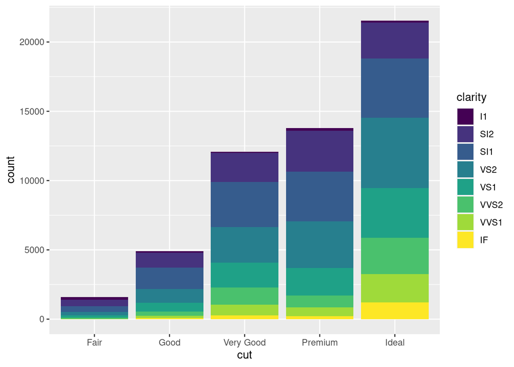

```r
ggplot(data=diamonds) +
  geom_bar(mapping = aes(x=cut, fill=clarity))
```

Ahora nuestro grafico muestra 40 combinaciones diferentes de corte y claridad, 5 categorias por 8 niveles diferentes de claridad. Cada combinacion tiene su propio bloque

ggplot2 tiene muchas mas figuras geometricas que se pueden utilizar, para conocerlas se puede consultar la documentacion de ggplot

#### Mas sobre el suavizado

A veces, puede ser difícil comprender tendencias en tus datos solo a través de diagramas de dispersión. El suavizado permite detectar una tendencia de datos aun cuando no puedes notar con facilidad una tendencia en los puntos de datos graficados. La funcionalidad de suavizado de ggplot2 es útil porque suma una l ínea de suavizado como otra capa en un diagrama; la línea de suavizado ayuda a ue un observador casual entienda el sentido de los datos.

##### Suavizado loess

Óptimo para suavizar diagramas con menos de 1000 puntos

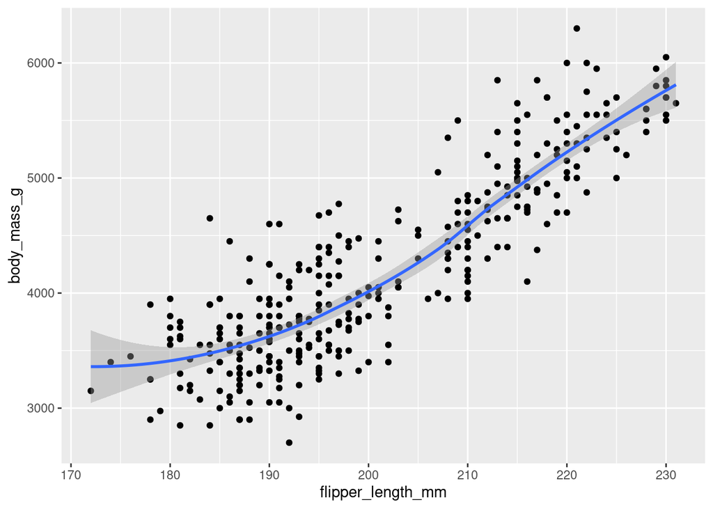

```r
ggplot(data=penguins) +
  geom_point(mapping = aes(x=flipper_length_mm,y=body_mass_g)) +
  geom_smooth(mapping=aes(x=flipper_length_mm,y=body_mass_g),method = "loess")
```

##### Suavizado gam

El suavizado con modelos aditivos generalizados, es útil para suavizar diagramas con un gran número de puntos

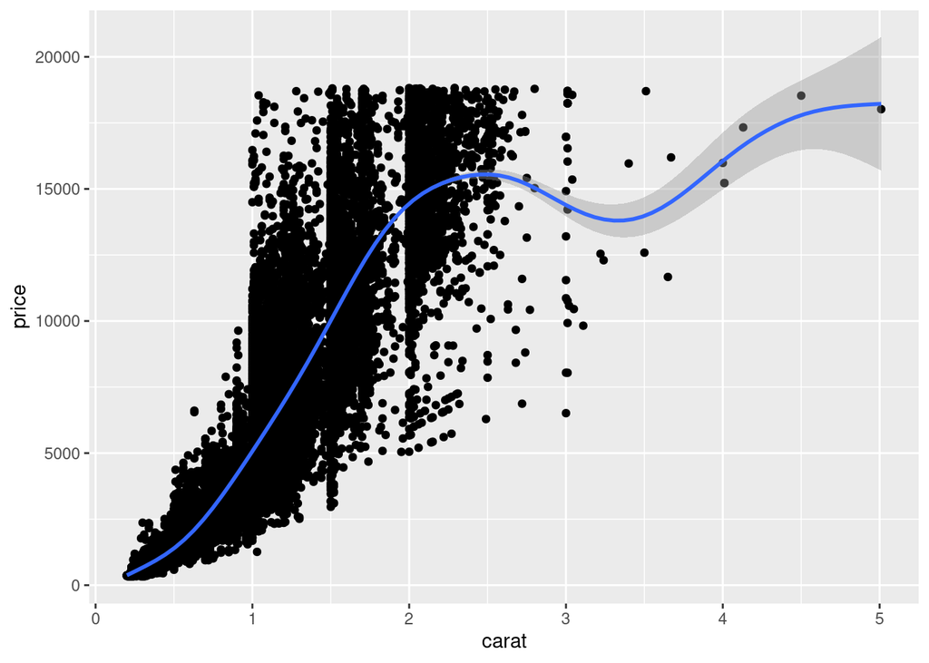

```r
ggplot(data=diamonds) +
  geom_point(mapping = aes(x=carat,y=price)) +
  geom_smooth(mapping=aes(x=carat,y=price),method = "gam",formula = y ~s(x))
```

La funcionalidad de suavizado en ggplot2 ayuda a que los diagramas de datos sean más legibles, para que puedas reconocer mejor las tendencias de datos y sacar conclusiones clave.

El método GAM (Generalized Additive Model) es una técnica de modelado estadístico que extiende los modelos lineales generalizados (GLM) permitiendo que las relaciones entre las variables predictoras y la variable de respuesta sean no lineales. Los modelos aditivos generalizados se construyen sumando funciones suavizadas de las variables predictoras.

En el código que proporcionaste, `geom_smooth` se utiliza con el método “gam” para realizar un suavizado de los datos. La función `s(x)` en la fórmula específica cómo se suaviza la relación entre las variables. Aquí hay una explicación más detallada: - **Método “gam”**: Indica que se está utilizando un modelo aditivo generalizado para realizar el suavizado. Este método es útil cuando se sospecha que la relación entre las variables no es estrictamente lineal y puede tener patrones más complejos.

- **`formula = y ~ s(x)`**: La fórmula especifica la relación entre la variable de respuesta (`y`) y la variable predictora (`x`). En este caso, se está utilizando una función suavizadora (`s()`) en la variable `x`. La función `s()` es responsable de suavizar la relación, permitiendo así que la relación sea no lineal.

En resumen, el código está creando un gráfico de dispersión (`geom_point`) de los datos diamonds con las variables `carat` en el eje x y `price` en el eje y. Luego, utiliza `geom_smooth` con el método “gam” y una fórmula que incluye una función suavizadora `s(x)` para mostrar una línea suavizada que representa la relación entre `carat` y `price`. Esto ayuda a visualizar tendencias más suaves y a identificar patrones en los datos que pueden no ser evidentes en el gráfico de dispersión original.

El código está creando un gráfico de dispersión (geom_point) de los datos diamonds con las variables carat en el eje x y price en el eje y. Luego, utiliza geom_smooth con el método “gam” y una fórmula que incluye una función suavizadora s(x) para mostrar una línea suavizada que representa la relación entre carat y price. Esto ayuda a visualizar tendencias más suaves y a identificar patrones en los datos que pueden no ser evidentes en el gráfico de dispersión original.

#### Estetica y facetas

Las facetas permite crear grupos mas pequeños o subconjutnos de datos. Las facetas muestran diferentes caras de los datos. El uso de facetas ayuda a descubrir nuevos patrones y enfocarte en relaciones entre diferentes variables.

ggplot2 tiene dos funciones para facetas: - facet_wrap() - facet_grid()

##### facet_wrap()

Nos sirve para crear subconjuntos a traves de una sola variable. Esto se ejemplifica con el conjunto de datos de pinguinos, en donde podriamos querer crear un diagrama por separado para cada especie.

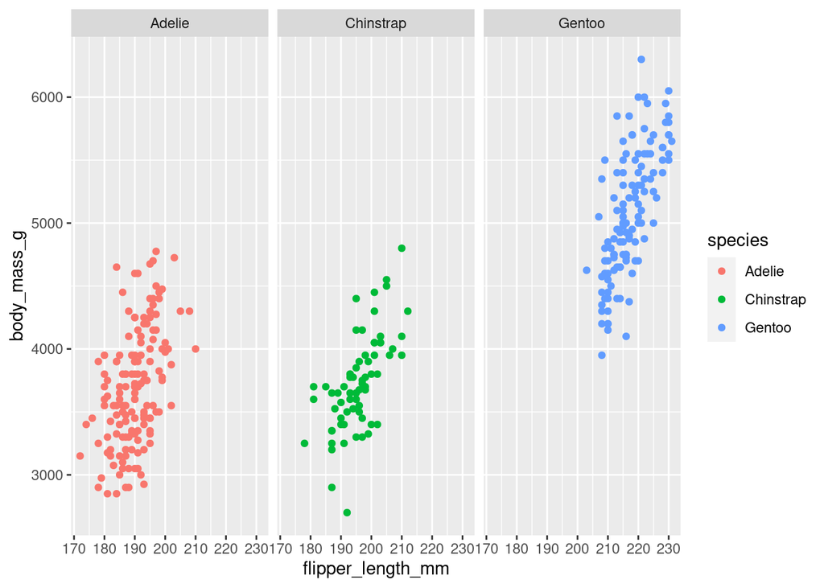

```r
ggplot(data=penguins) +
  geom_point(mapping = aes(x=flipper_length_mm,
                           y=body_mass_g, color=species)) +
  facet_wrap(~species)
```

Ejemplo con el conjunto de datos diamons

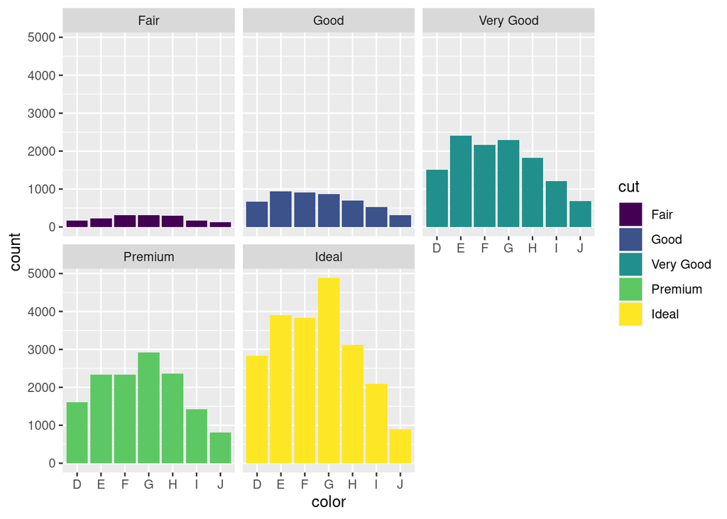

```r
ggplot(data=diamonds) +
  geom_bar(mapping = aes(x=color, fill=cut)) +
  facet_wrap(~cut)
```

Por ejemplo podemos tomar nuestro diagrama de pinguinos y usar facet_grid con las variables, sex y species

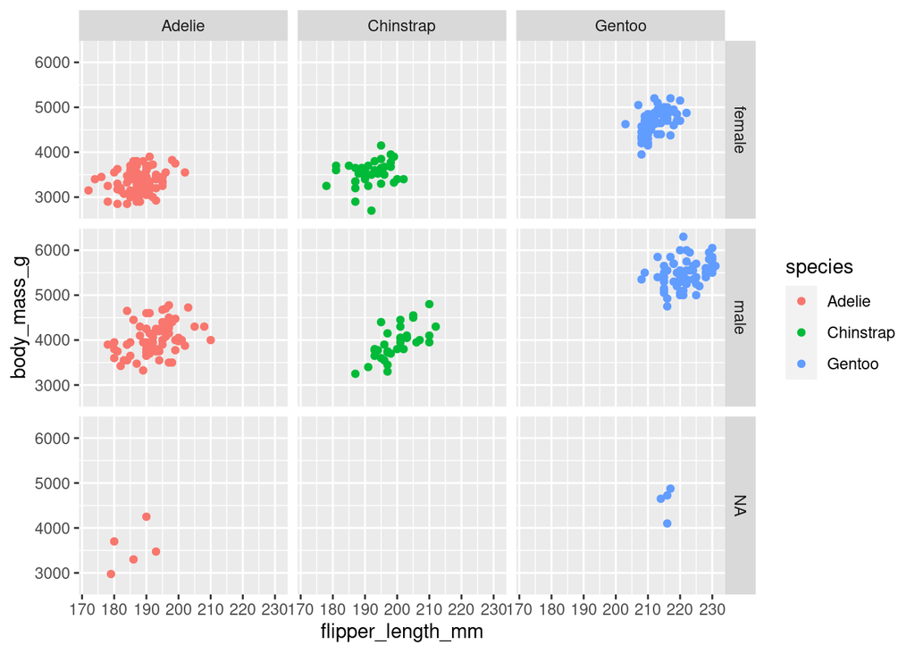

```r
ggplot(data=penguins) +
  geom_point(mapping = aes(x=flipper_length_mm,
                           y=body_mass_g, color=species)) +
  facet_grid(sex~species)
```

El codigo anterior crea 9 gráficos diferentes, hay 3 especies y 3 generos. Y cada grafico representa la relacion body_mass_g vs flipper_length_mm. con facet_grid() podemos reorganizar y mostrar con rapidez datos complejos y hace que sea más fácil ver realciones entre diferentes grupos.

#### Personalizando la apariencia de nuestros diagramas

##### Usando las funciones label y annotate

En ggplot2, agregar anotaciones a un diagrama puede ayudar a explicar el propósito del diagrama o a destacar datos importantes. Cuando presentas tus visualizaciones de datos a interesados, quizás no tengas mucho tiempo para reunirte con ellos. Las etiquetas y anotaciones dirigirán su atención a elementos clave y los ayudarán a comprender tu diagrama con rapidez.

###### label()

Es util para agregar etiquetas informativas a un diagrama, como titulos, subtitulos y leyendas

Agregando un titulo

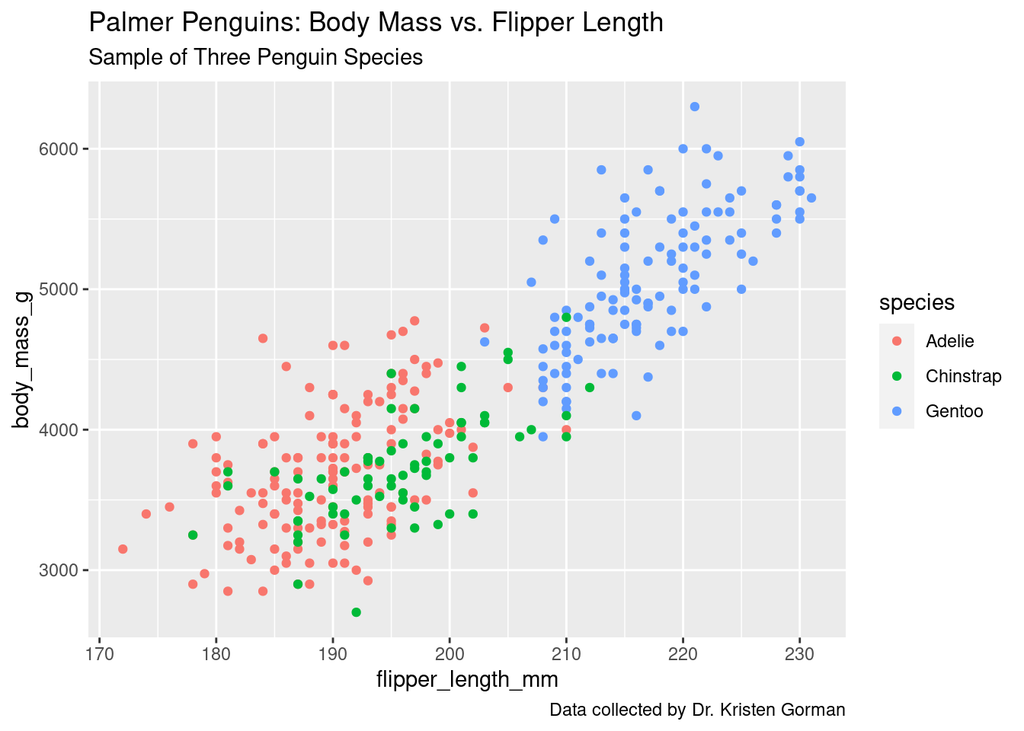

```r
ggplot(data = penguins) +
  geom_point(mapping = aes(x=flipper_length_mm, y=body_mass_g, color=species))+
  labs(title="Palmer Penguins: Body Mass vs. Flipper Length",
       subtitle = "Sample of Three Penguin Species",
       caption = "Data collected by Dr. Kristen Gorman")
```

Si queres ingresar texto dentro de la cuadricula para destacar puntos de datos especificos, utilzamos la siguiente funcion:

###### annotate()

Este texco comunica con claridad lo que muestra el diagrama y reforzará una parte importante de nuestros datos.

Los argumentos de la función annotate incluyen informacion sobre el tipo de etiqueta, coordenadas x e y donde se ubicara la etiqueta y el texto que incluirá la etiqueta.

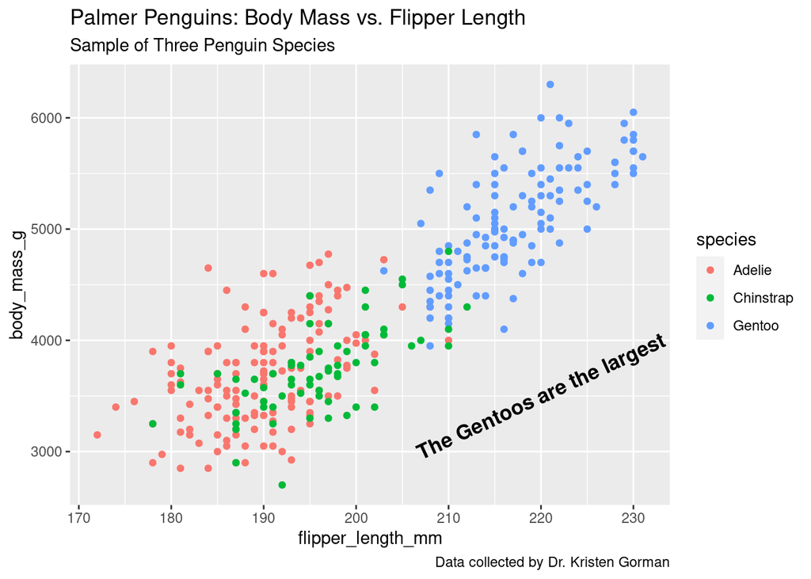

```r
ggplot(data = penguins) +
  geom_point(mapping = aes(x=flipper_length_mm, y=body_mass_g, color=species))+
  labs(title="Palmer Penguins: Body Mass vs. Flipper Length",
       subtitle = "Sample of Three Penguin Species",
       caption = "Data collected by Dr. Kristen Gorman") +
  annotate("text",
           x=220, y=3500,
           label= "The Gentoos are the largest",
           color="black",
           fontface="bold",size=4.5,angle=25)
```

##### Guardar visualizaciones

Poder reproducir y compartir nuestro trabajo es importante en el analisis de datos. Para lograr guardar nuestras visualizaciones utilizamos la opción exportar en la pestaña de daigramas de RStudio o la funcion ggsave() que ofrece el paquete ggplot2

###### Usando ggsave()

ggsave() es una funcion util para guardar un diagrama. De manera determinada guarda el último diagrama que ejecutaste y lo guarda del tamaño del dispositivo gráfico actual.